# Demo of Keras and Tensorflow in R

Author

Matthew V. Cannon

Published

December 5, 2024

```r
library(tensorflow)
library(keras)
library(Seurat)
library(reticulate)
library(tidyverse)
```

For documentation check out:

https://tensorflow.rstudio.com/

## Goal of the model

We’re going to build a model to predict cell types in a scRNAseq dataset. We’re going to use a portion of the expressed genes to make this prediction to save on computational time. Once we build a model, we’ll evaluate its accuracy and then use it to predict cell types in a test dataset.

## Get training data

From https://data.humancellatlas.org/hca-bio-networks/eye/atlases/retina-v1-0

- scRNA-seq of human retina - all cells
- 5 tissues
- Healthy tissue
- 265.8k cells

See data here: https://cellxgene.cziscience.com/e/be41a86a-b606-4b1c-8055-32f334898775.cxg/

I set this to eval: false so that the data isn’t downloaded every time the document is run. You can download the data by running the following command:

```bash
wget \
    -O neural_networks_2024/input/human_retina.rds \
    https://datasets.cellxgene.cziscience.com/64175889-d600-4b58-97ea-e74be80206e5.rds
```

## Read in the data

```r
sobj <- readRDS("input/human_retina.rds")

sobj
```

```
An object of class Seurat
36398 features across 265767 samples within 1 assay
Active assay: RNA (36398 features, 0 variable features)
 2 layers present: counts, data
 2 dimensional reductions calculated: scVI, umap
```

## Filter the data

```r
min_umis_per_cell <- 1000
sobj$crap <- sobj$nCount_RNA < min_umis_per_cell

table(sobj$cell_type, sobj$crap)
```

```
                                  FALSE  TRUE
  astrocyte                        2116   318
  microglial cell                  1297  1787
  amacrine cell                    1260   240
  retinal cone cell                3934  1877
  retinal rod cell                62146 27133
  Mueller cell                    42462  4783
  retinal ganglion cell             641     0
  retinal bipolar neuron          50322  8103
  rod bipolar cell                13692   671
  retinal pigment epithelial cell  1040   579
  S cone cell                       305    56
  H1 horizontal cell               4348  1107
  H2 horizontal cell               1741   117
  starburst amacrine cell           876   110
  midget ganglion cell of retina  10103     0
  parasol ganglion cell of retina   446     0
  GABAergic amacrine cell         11191  1221
  glycinergic amacrine cell        8437  1308
```

```r
sobj <- subset(sobj, crap == FALSE)

sobj$cell_type %>% table()
```

```
.
                      astrocyte                 microglial cell
                           2116                            1297
                  amacrine cell               retinal cone cell
                           1260                            3934
               retinal rod cell                    Mueller cell
                          62146                           42462
          retinal ganglion cell          retinal bipolar neuron
                            641                           50322
               rod bipolar cell retinal pigment epithelial cell
                          13692                            1040
                    S cone cell              H1 horizontal cell
                            305                            4348
             H2 horizontal cell         starburst amacrine cell
                           1741                             876
 midget ganglion cell of retina parasol ganglion cell of retina
                          10103                             446
        GABAergic amacrine cell       glycinergic amacrine cell
                          11191                            8437
```

## Get the most variable genes

We don’t want to use the entire dataset for this as it would take too long to run. Also, many of the genes in the dataset likely aren’t informative for cell type prediction. We’ll use only the top 500 most variable genes in the dataset as determined by Seurat. These genes should be the most informative for our model. I’ll also re-process the data for downstream analysis.

```r
# Lets use just a portion of the most variable genes
use_n_genes <- 500

sobj <-
    FindVariableFeatures(sobj, nfeatures = use_n_genes) %>%
    ScaleData() %>%
    RunPCA() %>%
    FindNeighbors() %>%
    FindClusters() %>%
    RunUMAP(dims = 1:30)
```

```
Modularity Optimizer version 1.3.0 by Ludo Waltman and Nees Jan van Eck

Number of nodes: 216357
Number of edges: 6191745

Running Louvain algorithm...
Maximum modularity in 10 random starts: 0.8898
Number of communities: 29
Elapsed time: 234 seconds
```

```r
qs::qsave(sobj, "output/rdata/processed_sobj.qs")
```

## Lets randomly assign the cells to training, testing, and validation sets

We’re going to need three datasets for this analysis. We’ll use 60% of the data for training, 20% for testing, and 20% for validation. We’ll also plot the UMAP of the data colored by cell type and dataset to make sure the cell types are distributed evenly across the datasets.

```r
set.seed(1337)
sobj$dataset <-
    sample(
        c("train", "test", "validation"),
        prob = c(0.6, 0.2, 0.2),
        nrow(sobj),
        replace = TRUE
    )

sobj$dataset %>% table()
```

```
.
      test      train validation
     43555     129731      43071
```

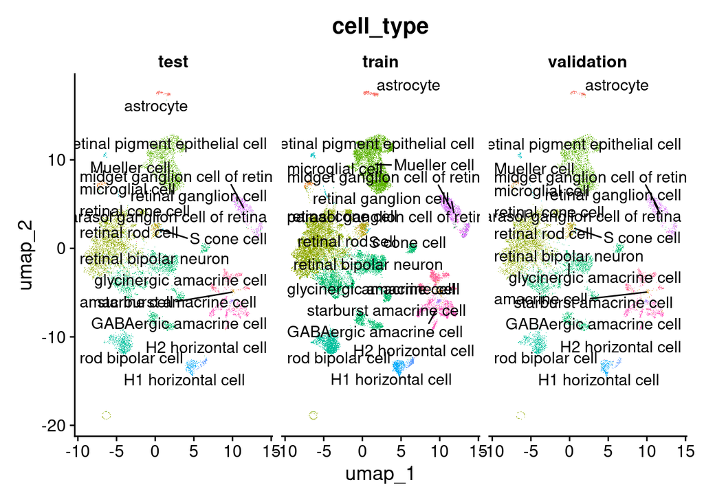

```r
DimPlot(
    sobj,
    group.by = "cell_type",
    split.by = "dataset",
    label = TRUE,
    repel = TRUE,
    raster.dpi = c(1024, 1024)
) +
    NoLegend()
```

```r
ggsave(
    "output/figures/umap_cell_type.png",
    width = 30,
    height = 10
)
```

## Lets pull out the data and scale it between 0 and 1 to make it friendly for the model

Neural networks don’t work well with large numbers and it is best to scale the data between 0 and 1. We’ll use the rank of the expression to scale it between 0 and 1. This will make the data more friendly for the model to work with. There are other ways I could have done this, but this is a simple way.

Note how the scaled data is originally well outside of 0 <-> 1, but is scaled to be between 0 and 1 after the scaling operation. I’m grabbbing the scale.data layer from the Seurat object so that lower expressed genes are still informative for the model.

```r
GetAssayData(sobj, layer = "scale.data")[, 1:10] %>%
    summary()
```

```
 GSM4081524_AAACGCTTCTTGGTCC-1 GSM4081524_AAAGGTACAATTGAGA-1
 Min.   :-0.61583              Min.   :-0.56884
 1st Qu.:-0.23962              1st Qu.:-0.19355
 Median :-0.11447              Median :-0.09399
 Mean   :-0.09776              Mean   : 0.02848
 3rd Qu.:-0.05394              3rd Qu.:-0.04394
 Max.   :10.00000              Max.   :10.00000
 GSM4081524_AAAGGTAGTGTTATCG-1 GSM4081524_AAAGTCCCAACCCGCA-1
 Min.   :-0.61583              Min.   :-0.61583
 1st Qu.:-0.23393              1st Qu.:-0.23393
 Median :-0.11034              Median :-0.11191
 Mean   :-0.03341              Mean   :-0.07739
 3rd Qu.:-0.05301              3rd Qu.:-0.05324
 Max.   :10.00000              Max.   :10.00000
 GSM4081524_AAAGTCCCATTAGGCT-1 GSM4081524_AAATGGATCTTCTGGC-1
 Min.   :-0.61583              Min.   :-0.58362
 1st Qu.:-0.18468              1st Qu.:-0.19180
 Median :-0.08951              Median :-0.09359
 Mean   : 0.01201              Mean   : 0.01981
 3rd Qu.:-0.03984              3rd Qu.:-0.04313
 Max.   : 3.79645              Max.   : 7.66109
 GSM4081524_AACAGGGCATCGCTCT-1 GSM4081524_AACCAACGTGGTCTGC-1
 Min.   :-0.58362              Min.   :-0.61583
 1st Qu.:-0.23075              1st Qu.:-0.18964
 Median :-0.10865              Median :-0.09338
 Mean   :-0.05460              Mean   : 0.07039
 3rd Qu.:-0.05185              3rd Qu.:-0.04158
 Max.   : 7.70918              Max.   :10.00000
 GSM4081524_AACCAACGTTGCGTAT-1 GSM4081524_AACCACAAGTTATGGA-1
 Min.   :-0.61583              Min.   :-0.61583
 1st Qu.:-0.24498              1st Qu.:-0.23962
 Median :-0.11722              Median :-0.11653
 Mean   :-0.13504              Mean   :-0.14479
 3rd Qu.:-0.05431              3rd Qu.:-0.05407
 Max.   :10.00000              Max.   : 2.47576
```

```r
scaled_counts <-
    GetAssayData(sobj, layer = "scale.data") %>%
    apply(
        MARGIN = 2,
        function(x) {
            rank(x) / length(x)
        }
    )

scaled_counts[, 1:10] %>%
    summary()
```

```
 GSM4081524_AAACGCTTCTTGGTCC-1 GSM4081524_AAAGGTACAATTGAGA-1
 Min.   :0.0020                Min.   :0.0020
 1st Qu.:0.2515                1st Qu.:0.2515
 Median :0.5010                Median :0.5010
 Mean   :0.5010                Mean   :0.5010
 3rd Qu.:0.7505                3rd Qu.:0.7505
 Max.   :1.0000                Max.   :1.0000
 GSM4081524_AAAGGTAGTGTTATCG-1 GSM4081524_AAAGTCCCAACCCGCA-1
 Min.   :0.0020                Min.   :0.0020
 1st Qu.:0.2515                1st Qu.:0.2515
 Median :0.5010                Median :0.5010
 Mean   :0.5010                Mean   :0.5010
 3rd Qu.:0.7505                3rd Qu.:0.7505
 Max.   :0.9990                Max.   :1.0000
 GSM4081524_AAAGTCCCATTAGGCT-1 GSM4081524_AAATGGATCTTCTGGC-1
 Min.   :0.0020                Min.   :0.0020
 1st Qu.:0.2515                1st Qu.:0.2515
 Median :0.5010                Median :0.5010
 Mean   :0.5010                Mean   :0.5010
 3rd Qu.:0.7505                3rd Qu.:0.7505
 Max.   :1.0000                Max.   :1.0000
 GSM4081524_AACAGGGCATCGCTCT-1 GSM4081524_AACCAACGTGGTCTGC-1
 Min.   :0.0020                Min.   :0.0020
 1st Qu.:0.2515                1st Qu.:0.2515
 Median :0.5010                Median :0.5010
 Mean   :0.5010                Mean   :0.5010
 3rd Qu.:0.7505                3rd Qu.:0.7505
 Max.   :1.0000                Max.   :1.0000
 GSM4081524_AACCAACGTTGCGTAT-1 GSM4081524_AACCACAAGTTATGGA-1
 Min.   :0.0020                Min.   :0.0020
 1st Qu.:0.2515                1st Qu.:0.2515
 Median :0.5010                Median :0.5010
 Mean   :0.5010                Mean   :0.5010
 3rd Qu.:0.7505                3rd Qu.:0.7505
 Max.   :1.0000                Max.   :1.0000
```

```r
dim(scaled_counts)
```

```
[1]    500 216357
```

## Create a category key

We’ll create a label key to keep track of the cell types and their corresponding numbers. Neural networks can only handle numbers, so if your data is text, like cell type labels, you’ll need to convert them to integers to use in the model. I’ll need to decode these values later on, so I’m creating a handy key variable to keep track of the cell types and their corresponding numbers. I’m also using data_labels later on to keep track of how many cell types I have.

```r
data_labels <-
    factor(
        as.character(sobj$cell_type),
        levels = sort(as.character(unique(sobj$cell_type)))
    )

data_numbers <- as.numeric(data_labels) - 1

label_key <-
    tibble(
        label_name = data_labels,
        label_number = data_numbers
    ) %>%
    distinct() %>%
    pull(label_name, name = "label_number")
```

## Split the data into training, testing, and validation sets

We’re going to need three datasets in this demo. We’ll use 60% of the data for training, 20% for testing, and 20% for validation.

The training data will be used to train the model, naturally.

The validation data will be used to tune the model’s hyperparameters during model fitting.

We use the testing data to evaluate how well the model generalizes to new data and check if the model is overfit.

```r
train_data <- scaled_counts[, sobj$dataset == "train"]
train_label_numbers <- data_numbers[sobj$dataset == "train"]

test_data <- scaled_counts[, sobj$dataset == "test"]
test_label_numbers <- data_numbers[sobj$dataset == "test"]

validation_data <- scaled_counts[, sobj$dataset == "validation"]
validation_label_numbers <- data_numbers[sobj$dataset == "validation"]
```

## Lets build a simple neural network to predict cell type from the expression data

I’m going to use a couple variables here to make sure the model can use my input data and I don’t have to manually change these values.

`number_of_cell_types` is the number of unique cell types in the dataset. This is used to determine the number of output nodes in the model.

`use_n_genes` is the number of genes we’re using in the model. This is the number of genes we used to scale the data earlier on. This is used to determine the number of input nodes in the model.

Building a model with keras is very similar to building a plot with ggplot2. You start with a base model and then add layers to it. Here I’m using a simple model with two hidden layers and a softmax output layer. We define the input_shape in the first dense layer to match the number of genes in our scaled data. When we train the model, the data from each cell will be fed into the model, which is why the input is equal to the number of genes. The final layer will output the probability of each cell type for each cell, which is why the number of output nodes is equal to the number of cell types.

The model is compiled with the adam optimizer and sparse categorical crossentropy loss function. The adam optimizer is a popular optimizer for neural networks that handles gradient descent for you.

The sparse categorical crossentropy loss function is used for classification problems where the output is a single integer representing the class. This is a good loss function for this dataset as the cell types are represented as integers. You may need to use a different loss function if your data is represented differently.

We begin by defining the structure of the model. This doesn’t build or train the data (we’ll do that later). This is just getting things set up.

Compiling the model sets the optimizer, loss function, and metrics for the model. This is where we define how the model will be trained. The optimizer is the algorithm that will be used to minimize the loss function. The loss function is the function that the model will try to minimize. The metrics are the values that will be printed out as the model trains. Here we’re using accuracy as the metric to print out as the model trains.

```r
number_of_cell_types <- length(unique(data_labels))
model <-
    keras_model_sequential() %>%
    layer_dense(
        units = 128,
        activation = "relu",
        input_shape = use_n_genes
    ) %>%
    layer_dense(
        units = 64,
        activation = "relu"
    ) %>%
    layer_dense(
        units = number_of_cell_types,
        activation = "softmax"
    )

model %>%
    compile(
        optimizer = 'adam',
        loss = 'sparse_categorical_crossentropy',
        metrics = c('accuracy')
    )

model
```

```
Model: "sequential"
________________________________________________________________________________
 Layer (type)                       Output Shape                    Param #
================================================================================
 dense_2 (Dense)                    (None, 128)                     64128
 dense_1 (Dense)                    (None, 64)                      8256
 dense (Dense)                      (None, 18)                      1170
================================================================================
Total params: 73554 (287.32 KB)
Trainable params: 73554 (287.32 KB)
Non-trainable params: 0 (0.00 Byte)
________________________________________________________________________________
```

## Fit the model

```r
fit_history_simple <-
    model %>%
    fit(
        t(train_data),
        train_label_numbers,
        epochs = 20,
        verbose = 2
    )
```

```
4055/4055 - 10s - loss: 0.2491 - accuracy: 0.9234 - 10s/epoch - 2ms/step
4055/4055 - 10s - loss: 0.1483 - accuracy: 0.9534 - 10s/epoch - 2ms/step
4055/4055 - 9s - loss: 0.1369 - accuracy: 0.9557 - 9s/epoch - 2ms/step
4055/4055 - 9s - loss: 0.1295 - accuracy: 0.9580 - 9s/epoch - 2ms/step
4055/4055 - 10s - loss: 0.1250 - accuracy: 0.9595 - 10s/epoch - 2ms/step
4055/4055 - 9s - loss: 0.1197 - accuracy: 0.9607 - 9s/epoch - 2ms/step
4055/4055 - 9s - loss: 0.1153 - accuracy: 0.9623 - 9s/epoch - 2ms/step
4055/4055 - 9s - loss: 0.1144 - accuracy: 0.9625 - 9s/epoch - 2ms/step
4055/4055 - 9s - loss: 0.1129 - accuracy: 0.9633 - 9s/epoch - 2ms/step
4055/4055 - 9s - loss: 0.1099 - accuracy: 0.9638 - 9s/epoch - 2ms/step
4055/4055 - 9s - loss: 0.1073 - accuracy: 0.9649 - 9s/epoch - 2ms/step
4055/4055 - 9s - loss: 0.1062 - accuracy: 0.9646 - 9s/epoch - 2ms/step
4055/4055 - 9s - loss: 0.1037 - accuracy: 0.9659 - 9s/epoch - 2ms/step
4055/4055 - 9s - loss: 0.1027 - accuracy: 0.9659 - 9s/epoch - 2ms/step
4055/4055 - 9s - loss: 0.1008 - accuracy: 0.9669 - 9s/epoch - 2ms/step
4055/4055 - 9s - loss: 0.1003 - accuracy: 0.9667 - 9s/epoch - 2ms/step
4055/4055 - 9s - loss: 0.0992 - accuracy: 0.9670 - 9s/epoch - 2ms/step
4055/4055 - 9s - loss: 0.0972 - accuracy: 0.9679 - 9s/epoch - 2ms/step
4055/4055 - 9s - loss: 0.0970 - accuracy: 0.9674 - 9s/epoch - 2ms/step
4055/4055 - 9s - loss: 0.0941 - accuracy: 0.9685 - 9s/epoch - 2ms/step
```

## Evaluate accuracy

Let’s see how well our model performs. We got some idea from the verbose output of the model as it trained, but we can get a more detailed look at the model’s performance by evaluating it on the *test data*. We’ll use the evaluate function to evaluate the model on the test data. This will give us the loss and accuracy of the model on the test data. We can use this information to see how well the model generalizes to new data. If we are overfitting, the model will perform poorly on the test data compared to the training data. If the model is underfitting, the model will perform poorly on both the training and test data. We can also plot the model’s accuracy and loss over time to see how the model is converging to assess if we should have trained the model longer.

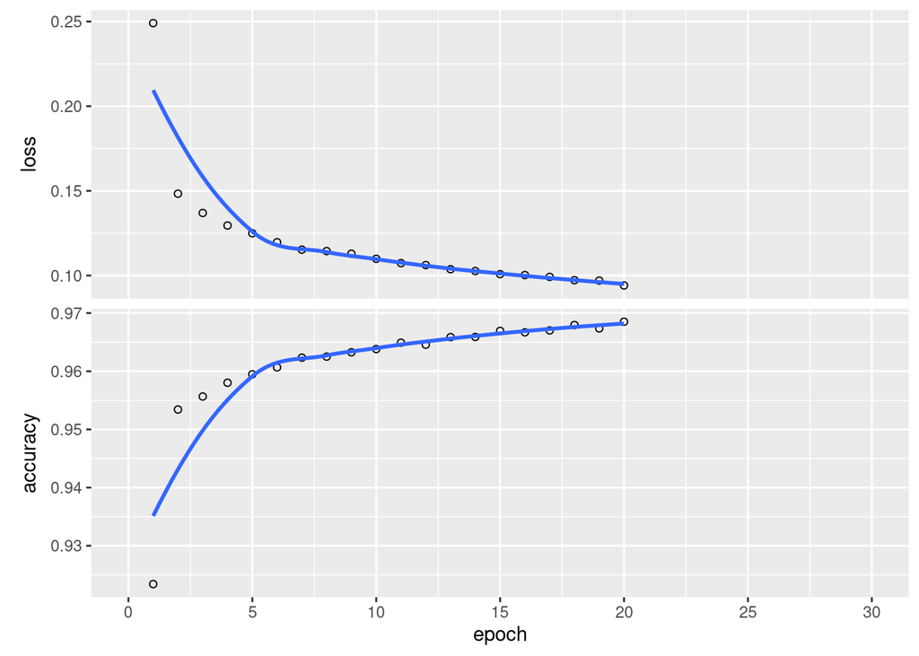

```r
fit_history_simple %>%
    plot() +
    coord_cartesian(xlim = c(0, 30))
```

```r
ggsave(
    "output/figures/fit_history_simple.png",
    width = 10,
    height = 10
)

model %>%
    evaluate(
        t(test_data),
        test_label_numbers,
        verbose = 0
    )
```

```
     loss  accuracy
0.1307954 0.9587648
```

## Predict cell types

Our model works ok, so lets try using it to predict cell types in the test dataset. We’ll use the predict function to predict the cell types in the test data. This will give us a matrix of probabilities for each cell type for each cell. We’ll then pick the cell type with the highest probability for each cell and use that as the predicted cell type. We’ll then add the predicted cell types to the Seurat object and plot the predicted cell types on the UMAP. We’ll also print out a confusion matrix to see how well the model predicted the cell types.

```r
predictions <-
    model %>%
    predict(t(test_data))
```

```
1362/1362 - 1s - 1s/epoch - 1ms/step
```

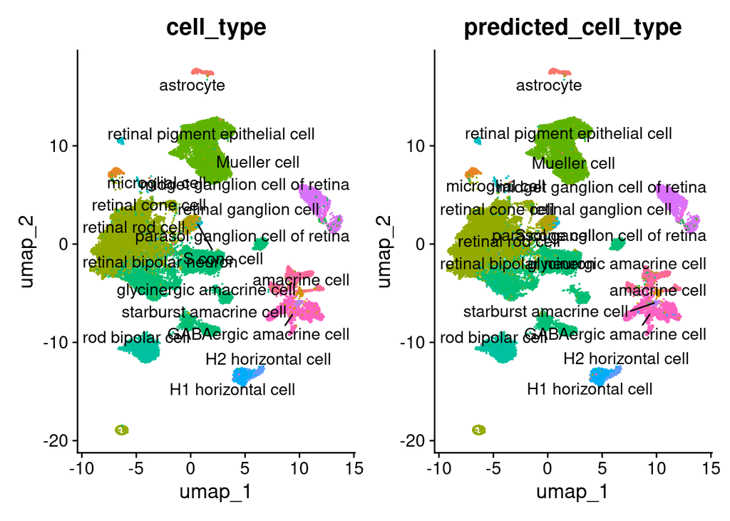

```r
predicted_labels <-
    parallel::mclapply(
        seq_len(nrow(predictions)),
        mc.cores = parallel::detectCores(),
        function(i) {
            x <- predictions[i,]
            tibble(
                max_call = which.max(x),
                picked_label = label_key[as.character(max_call - 1)]
            )
        }
    ) %>%
    bind_rows()

predicted_labels <-
    data.frame(
        predicted_cell_type = predicted_labels$picked_label,
        row.names = colnames(test_data)
    )

test_sobj <-
    subset(sobj, dataset == "test") %>%
    AddMetaData(
        metadata = predicted_labels,
        col.name = "predicted_cell_type"
    )

test_sobj$predicted_cell_type <-
    factor(
        test_sobj$predicted_cell_type,
        levels = levels(test_sobj$cell_type)
    )

(DimPlot(
    test_sobj,
    group.by = "cell_type",
    label = TRUE,
    repel = TRUE,
    raster.dpi = c(1024, 1024)
) +
    NoLegend()) +
(DimPlot(
    test_sobj,
    group.by = "predicted_cell_type",
    label = TRUE,
    repel = TRUE,
    raster.dpi = c(1024, 1024)
) +
    NoLegend())
```

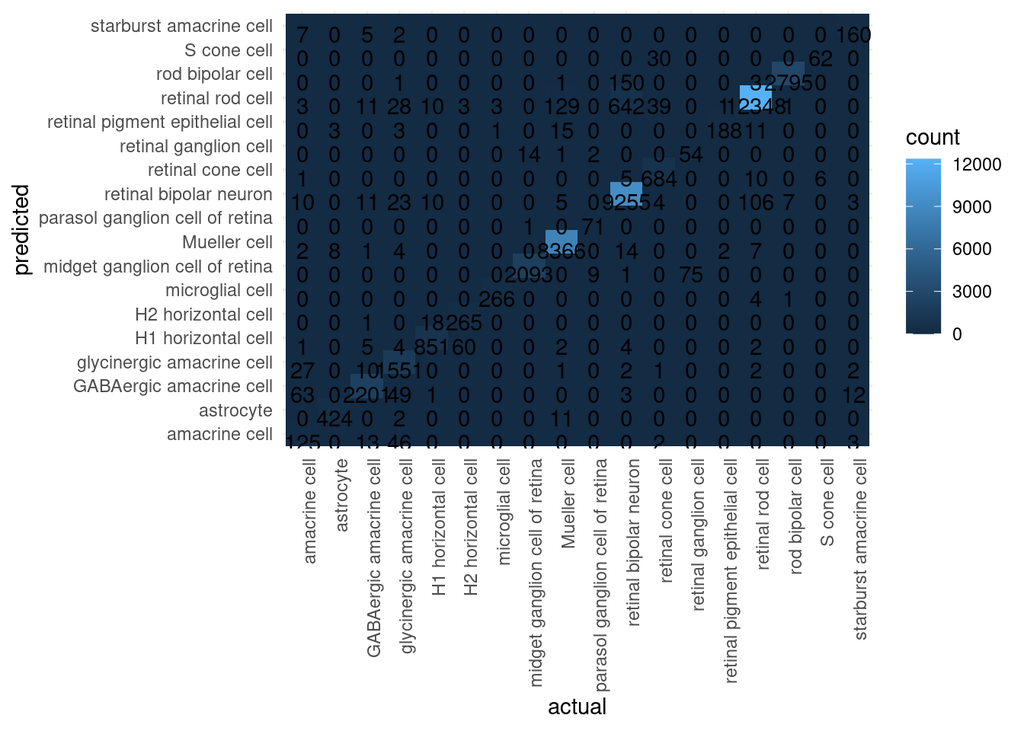

```r
ggsave(
    "output/figures/umap_predicted_cell_type.png",
    width = 30,
    height = 10
)

table(test_sobj$cell_type, test_sobj$predicted_cell_type) %>%
    as.data.frame() %>%
    rename(
        actual = Var1,
        predicted = Var2,
        count = Freq
    ) %>%
    mutate(actual = as.character(actual),
           predicted = as.character(predicted)) %>%
    ggplot(aes(x = actual, y = predicted, fill = count)) +
    geom_tile() +
    geom_text(aes(label = count), vjust = 1) +
    theme_minimal() +
    theme(axis.text.x = element_text(angle = 90, hjust = 1))
```

```r
ggsave(
    "output/figures/confusion_matrix.png",
    width = 10,
    height = 10
)
```

## Add a dropout layer

We have a lot of genes that are being fed into our model. This can lead to overfitting as the model may learn the noise in the data instead of the signal. To help prevent overfitting, we can add dropout layers to the model. Dropout layers randomly set a fraction of the input units to 0 at each step during training. This helps prevent the model from learning the noise in the data and helps the model generalize better to new data. We’ll add a dropout layer that sets 50% of the input units to 0.

```r
dropout_model <-
    keras_model_sequential() %>%
    layer_dense(
        units = 128,
        activation = "relu",
        input_shape = use_n_genes
    ) %>%
    layer_dropout(0.5) %>%
    layer_dense(
        units = 64,
        activation = "relu"
    ) %>%
    layer_dense(
        units = length(unique(data_labels)),
        activation = "softmax"
    )

dropout_model %>%
    compile(
        optimizer = 'adam',
        loss = 'sparse_categorical_crossentropy',
        metrics = c('accuracy')
    )
```

## Fit the model with dropout layers using validation data and early stopping

We’re going to do a few things differently here.

This time we will include validation data in the model fitting. During training, the model will train only on the training data still, but will evaluate the model on the validation data at each epoch. This will help us tune the model’s hyperparameters as we try re-training our model so that our test dataset is a true test of the model’s performance.

```r
model_fit_data <-
    fit(
        dropout_model,
        t(train_data),
        train_label_numbers,
        validation_data = list(t(validation_data), validation_label_numbers),
        epochs = 200,
        callbacks = callback_early_stopping(
            monitor = 'val_accuracy',
            patience = 5,
            min_delta = 0.01,
            restore_best_weights = TRUE
        ),
        verbose = 2
    )
```

```
4055/4055 - 13s - loss: 0.4397 - accuracy: 0.8634 - val_loss: 0.1770 - val_accuracy: 0.9416 - 13s/epoch - 3ms/step
4055/4055 - 12s - loss: 0.2724 - accuracy: 0.9127 - val_loss: 0.1519 - val_accuracy: 0.9499 - 12s/epoch - 3ms/step
4055/4055 - 12s - loss: 0.2453 - accuracy: 0.9211 - val_loss: 0.2011 - val_accuracy: 0.9290 - 12s/epoch - 3ms/step
4055/4055 - 12s - loss: 0.2275 - accuracy: 0.9281 - val_loss: 0.1482 - val_accuracy: 0.9510 - 12s/epoch - 3ms/step
4055/4055 - 12s - loss: 0.2171 - accuracy: 0.9312 - val_loss: 0.1580 - val_accuracy: 0.9484 - 12s/epoch - 3ms/step
4055/4055 - 12s - loss: 0.2120 - accuracy: 0.9331 - val_loss: 0.1378 - val_accuracy: 0.9576 - 12s/epoch - 3ms/step
4055/4055 - 12s - loss: 0.2080 - accuracy: 0.9344 - val_loss: 0.1643 - val_accuracy: 0.9476 - 12s/epoch - 3ms/step
4055/4055 - 12s - loss: 0.1998 - accuracy: 0.9368 - val_loss: 0.1407 - val_accuracy: 0.9569 - 12s/epoch - 3ms/step
4055/4055 - 12s - loss: 0.1963 - accuracy: 0.9379 - val_loss: 0.1402 - val_accuracy: 0.9552 - 12s/epoch - 3ms/step
4055/4055 - 12s - loss: 0.1914 - accuracy: 0.9403 - val_loss: 0.1424 - val_accuracy: 0.9560 - 12s/epoch - 3ms/step
4055/4055 - 12s - loss: 0.1906 - accuracy: 0.9400 - val_loss: 0.1473 - val_accuracy: 0.9520 - 12s/epoch - 3ms/step
```

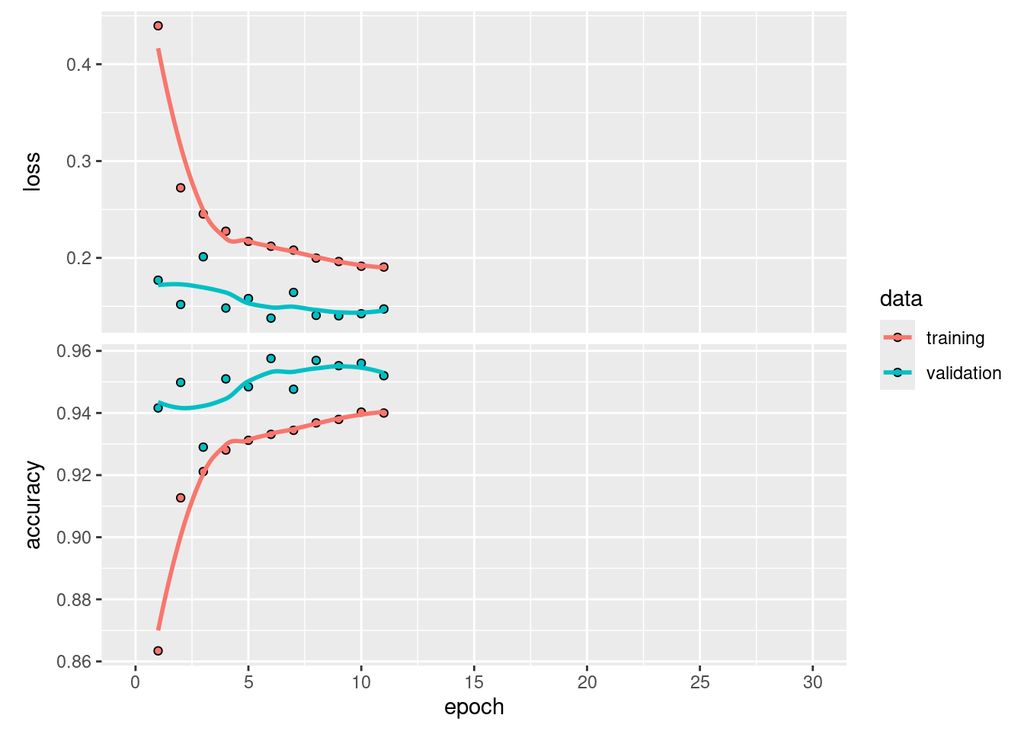

```r
model_fit_data %>%
    plot() +
    coord_cartesian(xlim = c(0, 30))
```

```r
ggsave(
    "output/figures/fit_history_dropout.png",
    width = 10,
    height = 10
)

evaluate(dropout_model, t(train_data), train_label_numbers)
```

```
4055/4055 - 4s - loss: 0.1327 - accuracy: 0.9583 - 4s/epoch - 956us/step
```

```
     loss  accuracy
0.1326770 0.9582829
```

```r
evaluate(dropout_model, t(test_data), test_label_numbers)
```

```
1362/1362 - 1s - loss: 0.1376 - accuracy: 0.9563 - 1s/epoch - 751us/step
```

```
     loss  accuracy
0.1376363 0.9563081
```

## Lets add a learning rate schedule so that the model takes smaller steps as it gets closer to optimum

By default, the learning rate of the model is the same as it trains. This can be problematic as the model gets more refined and closer to the optimum. Each step the model takes may end up overshooting optimal values over and over. By using a learning rate schedule, we can make the model take smaller steps as it gets closer to the optimum. This can help the model converge faster and more accurately.

All of the hyperparameters here can be adjusted to fit the model and data.

https://tensorflow.rstudio.com/guides/keras/training_with_built_in_methods#using-learning-rate-schedules

```r
steps_per_epoch <- 100

lr_schedule <-
    learning_rate_schedule_inverse_time_decay(
        initial_learning_rate = 0.001,
        decay_steps = 100000,
        decay_rate = 5,
        staircase = FALSE
    )

dropout_model %>%
    compile(
        optimizer = optimizer_adam(lr_schedule),
        loss = 'sparse_categorical_crossentropy',
        metrics = c('accuracy')
    )

fit_history <-
    dropout_model %>%
    fit(
        t(train_data),
        train_label_numbers,
        validation_data = list(t(validation_data), validation_label_numbers),
        epochs = 10,
        verbose = 2
    )
```

```
4055/4055 - 13s - loss: 0.2012 - accuracy: 0.9364 - val_loss: 0.1379 - val_accuracy: 0.9566 - 13s/epoch - 3ms/step
4055/4055 - 12s - loss: 0.1893 - accuracy: 0.9404 - val_loss: 0.1425 - val_accuracy: 0.9559 - 12s/epoch - 3ms/step
4055/4055 - 12s - loss: 0.1811 - accuracy: 0.9431 - val_loss: 0.1399 - val_accuracy: 0.9562 - 12s/epoch - 3ms/step
4055/4055 - 12s - loss: 0.1742 - accuracy: 0.9451 - val_loss: 0.1334 - val_accuracy: 0.9592 - 12s/epoch - 3ms/step
4055/4055 - 12s - loss: 0.1703 - accuracy: 0.9461 - val_loss: 0.1308 - val_accuracy: 0.9573 - 12s/epoch - 3ms/step
4055/4055 - 12s - loss: 0.1653 - accuracy: 0.9480 - val_loss: 0.1337 - val_accuracy: 0.9579 - 12s/epoch - 3ms/step
4055/4055 - 12s - loss: 0.1620 - accuracy: 0.9491 - val_loss: 0.1363 - val_accuracy: 0.9578 - 12s/epoch - 3ms/step
4055/4055 - 12s - loss: 0.1605 - accuracy: 0.9495 - val_loss: 0.1466 - val_accuracy: 0.9521 - 12s/epoch - 3ms/step
4055/4055 - 12s - loss: 0.1576 - accuracy: 0.9501 - val_loss: 0.1496 - val_accuracy: 0.9524 - 12s/epoch - 3ms/step
4055/4055 - 11s - loss: 0.1534 - accuracy: 0.9515 - val_loss: 0.1317 - val_accuracy: 0.9595 - 11s/epoch - 3ms/step
```

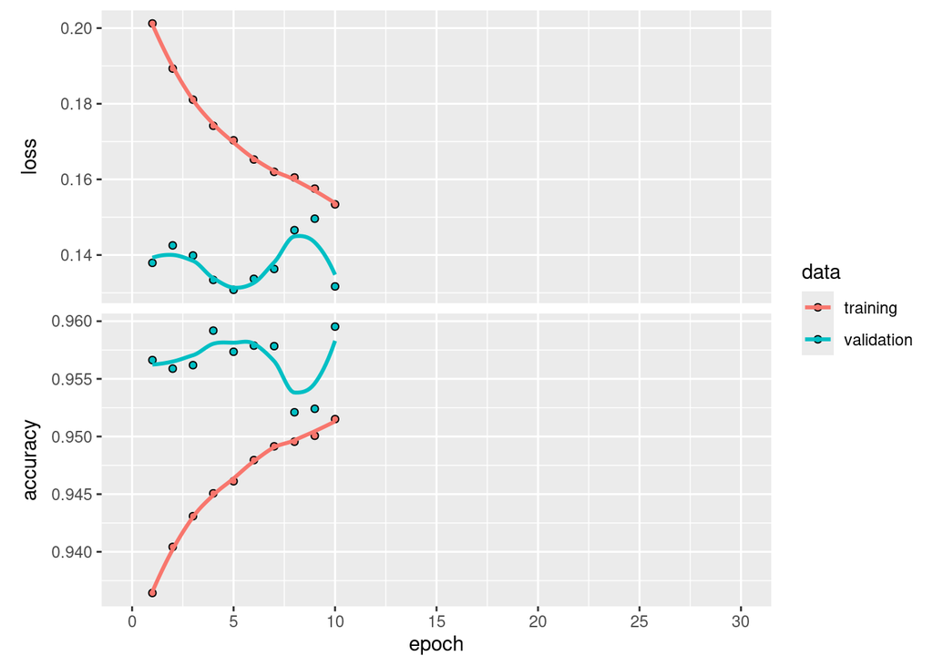

```r
fit_history %>%
    plot() +
    coord_cartesian(xlim = c(0, 30))
```

```r
ggsave(
    "output/figures/fit_history_slow_learning.png",
    width = 10,
    height = 10
)

evaluate(dropout_model, t(test_data), test_label_numbers)
```

```
1362/1362 - 1s - loss: 0.1326 - accuracy: 0.9591 - 1s/epoch - 1ms/step
```

```
     loss  accuracy
0.1326163 0.9591092
```

Some further considerations:

- We are assuming that the data are properly annotated in the first place. Hopefully this is true. But if the annotations are wrong, that may explain why our confusion matrix is not perfect. Our model could also be wrong, but it’s worth checking the annotations.
- We used the top 500 genes. This may have been not enough genes to predict the cell types accurately. We could try using more genes to see if that improves the model without impacting computational time or overfitting.
- I didn’t really try many model architectures. You’d likely want to try many different architectures to see which one works best for your data. This is a good starting point, but you’d likely want to try many more models to see which one works best. The validation data can help with this so that you can test the model’s performance on new data once you think it’s working well.